# Data_Preparation_and_Customer_Analytics

```python
import pandas as pd
import numpy as np
import matplotlib.pyplot as plt
import re
import seaborn as sns
from scipy import stats
```

## Quantium Data Analytics Virtual Experience Program

### Part 1 Data Preparation and customer analytics

by Murong (Sophie) Cui

Conduct analysis on your client's transaction dataset and identify customer purchasing behaviours to generate insights and provide commercial recommendations.

#### Table of Context

- Introduction
- DataSet
- Data Wrangling
- Data Analysis and Customer Segmentation
  - Sales by Customer Segment
  - Number of Customer by Customer Segment
  - Sales per Capita by Customer Segment
  - Number of Pack bought per transaction by Customer Segment
  - Unit Price bought by Customer Segment
- Target Customer Segment (Maintream - Young Singles/Couples)
  - Popular Brands for Target Customer Segment
  - T test for Unit Price (Mainstream young and midage singles/couples VS premium and budget young and midage singles/couples)
  - T test for Pack Size (target segment VS other segment)
- Insights

### Introduction

I am part of Quantium’s retail analytics team and have been approached by your client, the Category Manager for Chips, who wants to better understand the types of customers who purchase Chips and their purchasing behaviour within the region. The insights from my analysis will feed into the supermarket’s strategic plan for the chip category in the next half year.

Examine transaction data – look for inconsistencies, missing data across the data set, outliers, correctly identified category items, numeric data across all tables. Determining any anomalies make the necessary changes in the dataset and save it. Having clean data will help when it comes to the analysis.

Examine customer data – check for similar issues in the customer data, look for nulls and when I merge the transaction and customer data together so it’s ready for the analysis.

Data analysis and customer segments – in the analysis make sure to define the metrics – look at total sales, drivers of sales, where the highest sales are coming from etc. Explore the data, create charts and graphs as well as noting any interesting trends and/or insights found. These will all form part of our report to Julia.

Deep dive into customer segments – define recommendation from the insights, determine which segments we should be targeting, if packet sizes are relative and form an overall conclusion based on the analysis.

### Dataset

`transaction` dataframe is imported from `QVI_transaction_data.xlsx`: a year's worth of product transcations  
feature:

- DATE: the days after the base date (1899-12-30)
- STORE_NBR: the store ID number
- LYLTY_CARD_NBR: loyalty card id number
- TXN_ID: transaction ID
- PROD_NBR: Product ID Number
- PROD_NAME: product name
- PROD_QTY: product quantity sold
- TOT_SALES: total sales

`customer` dataframe is imported from `QVI_purchase_behavious.csv`: customer segmentation  
feature:

- LYLTY_CARD_NBR: loyalty card id number
- LIFESTAGE: customer attribute that identifies whether a customer has a family or not and what point in life they are at: RETIREES, OLDER SINGLES/COUPLES, YOUNG SINGLES/COUPLES, OLDER FAMILIES, YOUNG FAMILIES, MIDAGE SINGLES/COUPLES, NEW FAMILIES.
- PREMIUM_CUSTOMER: Customer segmentation used to differentiate shoppers by the price point of products they buy and the types of products they buy. It is used too identify whether customers may spend more for quality or brand or wehter they will purchase the cheapest options. Budget, Mainstream, Premium

```python
# import transaction data
transaction= pd.read_excel('data/QVI_transaction_data.xlsx')
```

```python
# data summary
print('df shape:', transaction.shape)
print('missing values:\n', transaction.isnull().sum())
print('description:\n',transaction.describe())
transaction.head()
```

```
df shape: (264836, 8)
missing values:
 DATE              0
STORE_NBR         0
LYLTY_CARD_NBR    0
TXN_ID            0
PROD_NBR          0
PROD_NAME         0
PROD_QTY          0
TOT_SALES         0
dtype: int64
description:
                 DATE     STORE_NBR  LYLTY_CARD_NBR        TXN_ID  \
count  264836.000000  264836.00000    2.648360e+05  2.648360e+05
mean    43464.036260     135.08011    1.355495e+05  1.351583e+05
std       105.389282      76.78418    8.057998e+04  7.813303e+04
min     43282.000000       1.00000    1.000000e+03  1.000000e+00
25%     43373.000000      70.00000    7.002100e+04  6.760150e+04
50%     43464.000000     130.00000    1.303575e+05  1.351375e+05
75%     43555.000000     203.00000    2.030942e+05  2.027012e+05
max     43646.000000     272.00000    2.373711e+06  2.415841e+06

            PROD_NBR       PROD_QTY      TOT_SALES
count  264836.000000  264836.000000  264836.000000
mean       56.583157       1.907309       7.304200
std        32.826638       0.643654       3.083226
min         1.000000       1.000000       1.500000
25%        28.000000       2.000000       5.400000
50%        56.000000       2.000000       7.400000
75%        85.000000       2.000000       9.200000
max       114.000000     200.000000     650.000000
```

|  | DATE | STORE_NBR | LYLTY_CARD_NBR | TXN_ID | PROD_NBR | PROD_NAME | PROD_QTY | TOT_SALES |
| --- | --- | --- | --- | --- | --- | --- | --- | --- |
| 0 | 43390 | 1 | 1000 | 1 | 5 | Natural Chip Compny SeaSalt175g | 2 | 6.0 |
| 1 | 43599 | 1 | 1307 | 348 | 66 | CCs Nacho Cheese 175g | 3 | 6.3 |
| 2 | 43605 | 1 | 1343 | 383 | 61 | Smiths Crinkle Cut Chips Chicken 170g | 2 | 2.9 |
| 3 | 43329 | 2 | 2373 | 974 | 69 | Smiths Chip Thinly S/Cream&Onion 175g | 5 | 15.0 |
| 4 | 43330 | 2 | 2426 | 1038 | 108 | Kettle Tortilla ChpsHny&Jlpno Chili 150g | 3 | 13.8 |

```python
# import purchase behaviour customer data
customer = pd.read_csv('data/QVI_purchase_behaviour.csv')
```

```python
# data summary
print(customer.LIFESTAGE.value_counts())
print(customer.PREMIUM_CUSTOMER.value_counts())
print(customer.isnull().sum())
customer.head()
```

```
RETIREES                  14805
OLDER SINGLES/COUPLES     14609
YOUNG SINGLES/COUPLES     14441
OLDER FAMILIES             9780
YOUNG FAMILIES             9178
MIDAGE SINGLES/COUPLES     7275
NEW FAMILIES               2549
Name: LIFESTAGE, dtype: int64
Mainstream    29245
Budget        24470
Premium       18922
Name: PREMIUM_CUSTOMER, dtype: int64
LYLTY_CARD_NBR      0
LIFESTAGE           0
PREMIUM_CUSTOMER    0
dtype: int64
```

|  | LYLTY_CARD_NBR | LIFESTAGE | PREMIUM_CUSTOMER |
| --- | --- | --- | --- |
| 0 | 1000 | YOUNG SINGLES/COUPLES | Premium |
| 1 | 1002 | YOUNG SINGLES/COUPLES | Mainstream |
| 2 | 1003 | YOUNG FAMILIES | Budget |
| 3 | 1004 | OLDER SINGLES/COUPLES | Mainstream |
| 4 | 1005 | MIDAGE SINGLES/COUPLES | Mainstream |

### Data Wrangling

- DATE
  > - Converting the days from base date to date
- PROD_NBR, PROD_NAME
  > - There are total 114 products sold. Some of them are salsa dipping sause. In order to find them out, the product table is extracted from the transaction table, containing 114 products (PROD_NBR, PROD_NAME). After investigating 114 products, there are 7 salsa products. Since we are inly interesting at the chips products, the records in transaction table only containing 7 salsa prodocts will be removed from the transaction table.  
  >   The 7 salsa products are (PROD_NBR, PROD_NAME):  
  >   35, Woolworths Mild Salsa 300g  
  >   76, Woolworths Medium Salsa 300g 57, Old El Paso Salsa Dip Tomato Mild 300g  
  >   59, Old El Paso Salsa Dip Tomato Med 300g  
  >   65, Old El Paso Salsa Dip Chnky Tom Ht300g  
  >   41, Doritos Salsa Mild 300g  
  >   101, Doritos Salsa Medium 300g
  > - Extracting the brand name (BRAND) from PROD_NAME
  > - Extracting the pack net weight (NET_WT) from PROD_NAME
- Outliers

  > By the boxplots of PROD_QTY and TOT_SALES, there are clearly outliers on both features and look at the trasaction table. I saw the the two records where 200 packets of Doritos chips are bought in one transaction made by same customer. It looks like this customer has only had the two transactions over the year and is not an ordinary retail customer. The customer are premium customer from elder family. The customer might be buying chips for commericial purposes instead. I remove this loyalty card number in the customer table and the transaction made by this loyalty card number in the transaction table.
- Time Series

  > These is one day missing was 2018-12-25 since all store close on Christmas day.  
  > Let's look at the number of transaction lines over time to see if there are any obvious data issues such as missing data. We see the increase in sales occurs in the lead-up to Christmas and that there are zero sales on Christmas day itself. This is due to shops being closed on Christmas day.
- NET_WT:

  > The largeest size is 380g and the smallest size is 70g. The distribution of pack size seems sensible
- BRAND:

  > After cleaning the brand name, the barplot of brand seems reasonable. 41288 transactions contains Kettle brand chips, making Kettle the most popular chip brand.
- UNIT PRICE:

  > Dividing TOT_SALES by PROD_QTY to get price by unit sold

```python
##### Correct Date Data Type
# date datatype
transaction['DATE'] = pd.to_datetime(transaction['DATE'], unit = 'D', origin = pd.Timestamp('1899-12-30'))
```

```python
##### Make product table and Exclude the salsa product
product = transaction[['PROD_NBR', 'PROD_NAME']].drop_duplicates()

# exclude the salsa product
mask = product['PROD_NBR'].isin([35, 76, 57, 59, 65, 41, 101])
product = product[~mask]
```

```python
# extract net weight
product['NET_WT'] = product.PROD_NAME.str.extract('(\d+)').astype(int)
product['PROD_NAME'] = product.PROD_NAME.str.replace('(\d+)[gG]', '')
```

```python
# correct erroneous brand name
product.loc[7, 'PROD_NAME'] = 'Sunbites Grain Waves Sweet Chilli'
product.loc[9, 'PROD_NAME'] = 'Sunbites Grain Waves Sour Cream&Chives'
product.loc[16, 'PROD_NAME'] = 'Smiths Burger Rings'
product.loc[56, 'PROD_NAME'] = 'Sunbites Grain Waves Plus Btroot & Chilli Jam'

incorrect_brandname = np.array(['NCC', 'Natural Chip        Compny', 'Natural Chip Co', 'Natural ChipCo',
                       'Smith ', 'Infzns', 'Red Rock Deli', 'Snbts', 'Dorito ', 'WW', 'French Fries', 'GrnWves'])
a = np.repeat('Natural_Chip_Company', 4)
correct_brandname = np.append(a, ['Smiths ', 'Infuzions', 'RRD', 'Sunbites', 'Doritos ', 'Woolworths', 'French_Fries', 'Grain Waves'])
brand_name_corrected = dict(zip(incorrect_brandname, correct_brandname))
# extract product name
product['PROD_NAME'] = product[['PROD_NAME']].replace(brand_name_corrected, regex=True)
product['BRAND'] = product['PROD_NAME'].str.split(' ', 1, expand = True)[0]
```

```python
# construct the product table
product = product[['PROD_NBR', 'NET_WT', 'BRAND']]
product.head()
```

|  | PROD_NBR | NET_WT | BRAND |
| --- | --- | --- | --- |
| 0 | 5 | 175 | Natural_Chip_Company |
| 1 | 66 | 175 | CCs |
| 2 | 61 | 170 | Smiths |
| 3 | 69 | 175 | Smiths |
| 4 | 108 | 150 | Kettle |

```python
# join the product table back into the transaction table
# transaction.merge(product, how = 'inner', on = 'PROD_NBR')
```

```python
##### Missing one date
a = set(transaction.DATE.to_list())
b = set(pd.date_range(start=transaction.DATE.min(), end=transaction.DATE.max(), freq='D').to_list())
print('one missiing day is ', b-a)
```

```
one missiing day is  {Timestamp('2018-12-25 00:00:00', freq='D')}
```

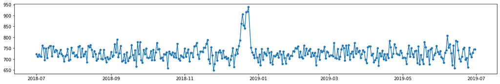

```python
plt.figure(figsize = (20, 3))
sns.lineplot(x = transaction.DATE.value_counts().index ,
             y = transaction.DATE.value_counts().values);
sns.scatterplot(x = transaction.DATE.value_counts().index ,
             y = transaction.DATE.value_counts().values,
                s = 30);
```

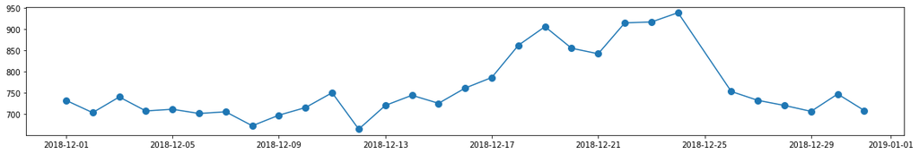

```python
dec_tran = transaction[transaction.DATE.dt.month == 12]
plt.figure(figsize = (20, 3))
sns.lineplot(x = dec_tran.DATE.value_counts().index ,
             y = dec_tran.DATE.value_counts().values);
sns.scatterplot(x = dec_tran.DATE.value_counts().index ,
             y = dec_tran.DATE.value_counts().values,
                s = 100);
```

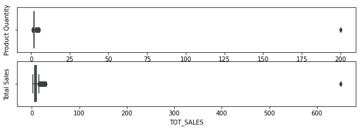

```python
##### exclude outliers

plt.figure(figsize = (10, 3))

plt.subplot(2,1,1)
sns.boxplot(x = 'PROD_QTY', data = transaction);
plt.ylabel('Product Quantity')

plt.subplot(2,1,2)
sns.boxplot(x = 'TOT_SALES', data = transaction);
plt.ylabel('Total Sales')
#ax2 = sns.boxplot(x = 'TOT_SALES', data = transaction);
```

```python
# drop LYLTY_CARD_NBR 22600 from both
transaction = transaction[transaction.LYLTY_CARD_NBR != 226000]
customer = customer[customer.LYLTY_CARD_NBR != 226000]
```

```python
# remove multiple spaces in Prod_name
transaction['PROD_NAME'] = transaction.PROD_NAME.replace('\s+', ' ', regex=True)
```

```python
# merging product table to
transaction =  transaction.merge(product, how = 'inner', on = 'PROD_NBR')
```

```
Smallest Pack Size: 70 Largest Pack Size: 380
```

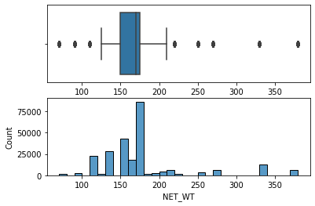

```python
# check pack size
print('Smallest Pack Size:', transaction.NET_WT.min(), 'Largest Pack Size:', transaction.NET_WT.max())
plt.subplot(2,1,1)
sns.boxplot(x = transaction['NET_WT']);
plt.subplot(2,1,2)
sns.histplot(data = transaction, x = 'NET_WT', binwidth = 10);
```

```
Kettle                  41288
Smiths                  33387
Doritos                 25224
Pringles                25102
RRD                     17779
Infuzions               14201
Thins                   14075
Woolworths              11836
Sunbites                10748
Cobs                     9693
Tostitos                 9471
Twisties                 9454
Natural_Chip_Company     7469
Tyrrells                 6442
Cheezels                 4603
CCs                      4551
Cheetos                  2927
French_Fries             1418
Name: BRAND, dtype: int64
```

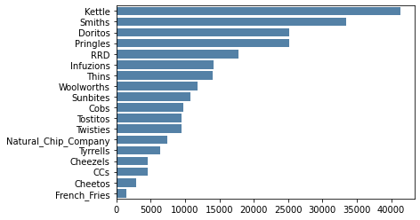

```python
# check brand
print(transaction.BRAND.value_counts())
sns.barplot(x = transaction.BRAND.value_counts().values, y = transaction.BRAND.value_counts().index, color = 'steelblue')
```

```python
# merge transaction and customer
transaction_customer = transaction.merge(customer, on='LYLTY_CARD_NBR', how = 'left')
```

```python
# feature engineering: unit_price, combine two cusomter segment: lifestage + premium customer
transaction_customer['UNIT_PRICE'] = transaction_customer['TOT_SALES'].astype('float')/transaction_customer['PROD_QTY'].astype('float')
transaction_customer['LIFESTAGE_PREMIUM'] = transaction_customer['LIFESTAGE']+ '-'+ transaction_customer['PREMIUM_CUSTOMER']


transaction_customer.head()
```

|  | DATE | STORE_NBR | LYLTY_CARD_NBR | TXN_ID | PROD_NBR | PROD_NAME | PROD_QTY | TOT_SALES | NET_WT | BRAND | LIFESTAGE | PREMIUM_CUSTOMER | UNIT_PRICE | LIFESTAGE_PREMIUM |
| --- | --- | --- | --- | --- | --- | --- | --- | --- | --- | --- | --- | --- | --- | --- |
| 0 | 2018-10-17 | 1 | 1000 | 1 | 5 | Natural Chip Compny SeaSalt175g | 2 | 6.0 | 175 | Natural_Chip_Company | YOUNG SINGLES/COUPLES | Premium | 3.0 | YOUNG SINGLES/COUPLES-Premium |
| 1 | 2018-12-05 | 5 | 5050 | 4667 | 5 | Natural Chip Compny SeaSalt175g | 2 | 6.0 | 175 | Natural_Chip_Company | MIDAGE SINGLES/COUPLES | Budget | 3.0 | MIDAGE SINGLES/COUPLES-Budget |
| 2 | 2018-08-04 | 16 | 16364 | 14497 | 5 | Natural Chip Compny SeaSalt175g | 1 | 3.0 | 175 | Natural_Chip_Company | MIDAGE SINGLES/COUPLES | Budget | 3.0 | MIDAGE SINGLES/COUPLES-Budget |
| 3 | 2018-07-18 | 35 | 35359 | 31902 | 5 | Natural Chip Compny SeaSalt175g | 1 | 3.0 | 175 | Natural_Chip_Company | MIDAGE SINGLES/COUPLES | Budget | 3.0 | MIDAGE SINGLES/COUPLES-Budget |
| 4 | 2019-05-06 | 39 | 39167 | 35645 | 5 | Natural Chip Compny SeaSalt175g | 2 | 6.0 | 175 | Natural_Chip_Company | MIDAGE SINGLES/COUPLES | Budget | 3.0 | MIDAGE SINGLES/COUPLES-Budget |

```python
# save the dataset
# transaction_customer.to_csv('transaction_customer.csv', index = False, header = True)
```

### Data Analysis and Customer Segmentation

Now that data is ready for analysis, we can define some metrics of interset to the client:

- Who spends the most on chips (total sales), describing customer by lifestage and how premium their general pruchasing behaviour is
- How many customers are in each segment
- How many chips are bought per customer by segment
- What's the average chip price by customer segment

```python
def groupby_df(group_feature, target_feature, agg_method, df = transaction_customer):
    '''
    df: transaction_customer (default),
    group_feature: df grouped by the group_feature,
    target_feature: target feature
    '''

    temp = df\
    .groupby(group_feature)[[target_feature]]\
    .agg(agg_method)\
    .sort_values(target_feature, ascending = False)\
    .reset_index()

    temp['LIFESTAGE_PREMIUM'] = temp['LIFESTAGE']+'-'+temp['PREMIUM_CUSTOMER']

    return temp



def groupby_df_self_agg(group_feature, target_feature, agg_method, df = transaction_customer):
    '''
    df: transaction_customer (default),
    group_feature: df grouped by the group_feature,
    target_feature: target feature
    '''

    temp = df\
    .groupby(group_feature)[[target_feature]]\
    .agg(agg_method)\
    .reset_index()

    temp['sales_per_capita'] = temp[target_feature][agg_method[0]]/temp[target_feature][agg_method[1]]

    temp.columns = ['_'.join(col).rstrip('_') for col in temp.columns.values]

    temp['LIFESTAGE_PREMIUM'] = temp['LIFESTAGE']+'-'+temp['PREMIUM_CUSTOMER']

    temp = temp.sort_values('sales_per_capita', ascending = False).reset_index()

    return temp



def plot_barplot(df, feature_target):
    sns.barplot(y = 'LIFESTAGE_PREMIUM', x=feature_target, data = df, color = 'steelblue');
    for i in range(len(df)):
        count = df[feature_target][i]
        pct_string = '{0:.3f}'.format(count)
        plt.text(count + 0.1, i, pct_string, va='center')
    sns.despine();
    plt.xlabel('{} ($)'.format(feature_target))
    plt.show()
```

**- Who spends the most on chips (total sales), describing customer by lifestage and how premium their general pruchasing behaviour is**

Top total sales are coming from Order Family - Budget, Young Singles/Couples - Mainstream, Retirees - Mainstream

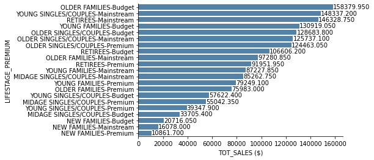

```python
plot_barplot(groupby_df(['LIFESTAGE', 'PREMIUM_CUSTOMER'], 'TOT_SALES', 'sum'), 'TOT_SALES')
```

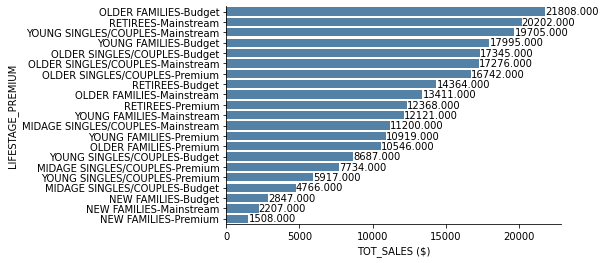

```python
plot_barplot(groupby_df(['LIFESTAGE', 'PREMIUM_CUSTOMER'], 'TOT_SALES', 'count'), 'TOT_SALES')
```

**- How the sales per capita are in each segment**

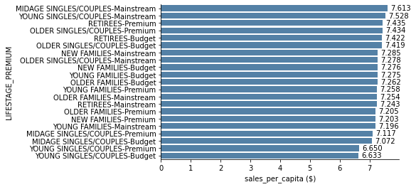

```python
plot_barplot(groupby_df_self_agg(['LIFESTAGE', 'PREMIUM_CUSTOMER'], 'TOT_SALES', ['sum', 'count']), 'sales_per_capita')
```

**- How many chips are bought per customer by segment**

Higher sales may also be driven by more units of chips being bought per customer. So we calculate the average number of units per customer by lifestage and premium status.

Older families and young families in general buy more per customer

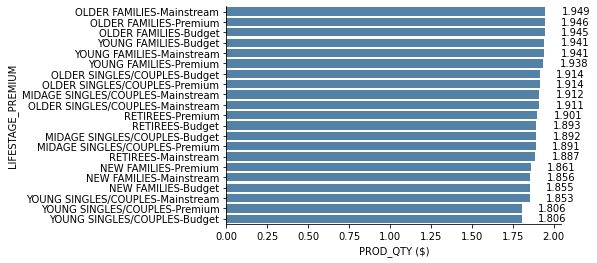

```python
plot_barplot(groupby_df(['LIFESTAGE', 'PREMIUM_CUSTOMER'], 'PROD_QTY', 'mean'), 'PROD_QTY')
```

**- What's the average chip price by customer segment**

We also investigate the averrage price per unit chips bought for each customer segment as this is also a driver of total sales. We calculate average price per unit by lifestage and premium status.

Mainstream Midage and Young Singles/Couples are more willing to pay more per packet of chips compared to their budget and premium counterrparts. This may be due to premium shoppers being more likely to buy healthy snacks and when they buy chips, this is mainly for entertainment purposes rather than their own consuption. This is also supported by there mainstream counterparts.

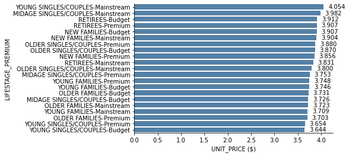

```python
plot_barplot(groupby_df(['LIFESTAGE', 'PREMIUM_CUSTOMER'], 'UNIT_PRICE', 'mean'), 'UNIT_PRICE')
```